# An introduction to generalized hypergeometric ensembles (gHypEG) regressions.

Giona Casiraghi

Chair of Systems Design, ETH Zurich, Switzerland  
gcasiraghi@ethz.ch

Laurence Brandenberger

Chair of Systems Design, ETH Zurich, Switzerland  
lbrandenberger@ethz.ch

2026-02-04

# Introduction

The Package is used to run inferential models on multi-edge networks. This vignette guides through the data preparation and model estimation and assessment steps needed to perform network regressions on multi-edge networks. This vignette is split into 3 distinct parts

1. Part 1: Data preparation
2. Part 2: Running gHypEG regressions
3. Part 3: Model assessment, simulations and goodness-of-fit

The vignette builds on a multi-edge network of Swiss members of Parliament. The data set is contained in the package for easy loading. The data set records co-sponsorship activities of 163 members of the Swiss National Council (in German: Nationalrat). Whenever a member of parliament (MP) drafts a new legislation (or bill), poses a question to the Federal Council (in German: Bundesrat), issues a motion or petition, they are allowed to add co-signatories (or co-sponsors) to the proposal. These co-sponsorship signatures act as a measure of support and signals the relevance of the proposal. As MPs can submit multiple proposals during the course of their service in parliament, each MP can support another MP multiple times, resulting in a multi-edge network of support among MPs.

# Part 1: Data preparation

## Loading package and data

```r
library(ghypernet)
library(texreg, quietly = TRUE) # for regression tables
```

```r
library(ggplot2) # for plotting
library(ggraph) #for network plots using ggplot2
```

After loading the package, the included data set on Swiss MPs can be used (already lazy loaded).

The data set contains four objects:

1. **cospons_mat**: contains the adjacency matrix of 163 x 163 MPs. It contains the number of times one MP (rows) supports the submitted proposals of another MP (columns).
2. **dt**: contains different attributes of the 163 MPs, such as their names, their party affiliation (variable: *party*), their parliamentary group affiliation (variable: *parlGroup*), the Canton (or state) they represent (variable: *canton*), their gender (variable: *gender*) and date of birth (variable: *birthdate*).
3. **dtcommittee**: a list of committees each MP was part of during their stay in parliament
4. **onlinesim_mat**: a similarity matrix of how similar two MPs are in their online social media presence (shared supportees).

## Network data manipulations

The above data is coded in an adjacency matrix. However, most often, network data is stored in the more efficient edge list format. Two functions help move from one format to another:

```r
el <- adj2el(cospons_mat, directed = TRUE)
```

The `adj2el()`-function transforms an adjacency matrix into an edgelist. By specifying `directed = FALSE`, only the top triangle of the adjacency matrix is stored in the edgelist (making it more efficient to handle, especially for large networks).

Edgelists also allow you to check basic statics about your network, such as average degree or the degree distribution.

```r
summary(el$edgecount)
```

```
#>    Min. 1st Qu.  Median    Mean 3rd Qu.    Max.
#>   1.000   1.000   2.000   3.854   4.000  75.000
```

The function `el2adj` transforms an edgelist into an adjacency matrix.

```r
nodes <- colnames(cospons_mat)
adj_mat <- el2adj(el, nodes = nodes)
```

Since edgelists (often) do not store isolate nodes in the network, the function takes a `nodes`-attribute. By specifying the nodes attribute, all all nodes (including isolate nodes) are included in the adjacency matrix.

```r
identical(cospons_mat, adj_mat)
```

```
#> [1] TRUE
```

## Compiling nodal attribute data

When preparing nodal attribute data, particular attention has to be given to the ordering of the two data sets (the adjacency matrix and the attribute data set). Testing whether the adjacency matrix and the attribute data are ordered by the same identifiers (here by the ID codes of the individual MPs, `dt$idMP`), attribute-based independent and control variables will correspond with the dependent variable.

```r
identical(rownames(cospons_mat), dt$idMP)
```

```
#> [1] TRUE
```

In case, the above test-code yields `FALSE`, the attribute data needs to be ordered.

Let’s assume, our attribute data set `dt_unsorted` is sorted differently:

```r
dt_unsorted <- dt[order(dt$firstName),]
identical(rownames(cospons_mat), dt_unsorted$idMP)
```

```
#> [1] FALSE
```

The simplest way is to proceed is to create a new data frame with the rownames (or colnames) of the adjacency matrix, then merging the attribute data in.

```r
dtsorted <- data.frame(idMP = rownames(cospons_mat))
dtsorted <- dplyr::left_join(dtsorted, dt_unsorted, by = "idMP")
identical(dt$idMP, dtsorted$idMP)
```

```
#> [1] TRUE
```

Learn more about data joins [here](https://www.r-bloggers.com/2018/10/how-to-perform-merges-joins-on-two-or-more-data-frames-with-base-r-tidyverse-and-data-table/).

## Independent and control variables

To estimate effects of endogenous and exogenous factors (i.e., independent and control variables) on the multi-edge network, covariates have to be fed into the gHypEG regression as matrices with the same dimensions as the multi-edge network (i.e., the dependent variable).

```r
dim(cospons_mat) == dim(onlinesim_mat)
```

```
#> [1] TRUE TRUE
```

Additionally, it is prudent to make sure that all covariates have the same row- and column-names:

```r
table(rownames(cospons_mat) == rownames(onlinesim_mat))
```

```
#>
#> TRUE
#>  163
```

### The role of zero-values in covariates

The gHypEG regression is zero-sensitive. Zero value entries in covariates signify structural zeros and are not considered in the estimation process. Therefore, all zero-values that do not signify structural zeros need to be recoded. The best solution is to the define a dummy variable that encodes zero and non-zero values to be used together with the covariate of interest. In this way, zero values are accounted separately in the regression process and do not enforce structural zeroes in the network.

### Change statistics to calculate endogenous network statistics

Change statistics (or change scores) can be used to model endogenous network properties in inferential network models [@snijders2006new, @hunter2008goodness, @krivitsky2011adjusting]. For each dyad in the multi-edge network, the change statistic captures the (un-)weighted values of additional edges involved in the interested network pattern. See Brandenberger et al. [-@brandenberger2019quantifying] for additional information on change statistics for multi-edge networks.

### Reciprocity

The `reciprocity_stat()`-function can be used to calculate weighted reciprocity change statistic. Since it’s dyad-independent, it can be used as a predictor in the gHypEG regression.

The function takes either a matrix or an edgelist. If an edgelist is provided, the `nodes`-object can be specified again to ensure that isolates are included as well.

```r
recip_cospons <- reciprocity_stat(cospons_mat)
recip_cospons[1:5, 1:3]
```

```
#>                     Andreas Broennimann Ueli Maurer Markus Hutter
#> Andreas Broennimann                   0           0             0
#> Ueli Maurer                           0           0             0
#> Markus Hutter                         2           1             0
#> Hansruedi Wandfluh                    0           1             0
#> Thomas Matter                         0           0             0
```

The resultant matrix measures reciprocity by checking for each dyad $(i, j)$, how many edges were drawn from $(j, i)$. If reciprocity is a driving force in the network, taking the transpose of the matrix should correlate strongly with the co-sponsorship matrix.

The `zero_values`-argument allows for the specification of minimum values. By default, 0 used.

### Triadic closure

The `sharedPartner_stat()`-function provides change statistics to check your multi-edge network for meaningful triadic closure effects. Triadic closure refers to the important tendency observed in social networks to form triangles, or triads, between three nodes $i$, $j$ and $i$. If dyad $(i, k)$ are connected, and dyad $(j, k)$ are connected, there is a strong tendency in some social networks that dyad $(i, j)$ also shares an edge (see Figure 1a and 1b).

The `sharedPartner_stat()`-function uses the concept of shared partner statistics to calculate the tendencies of nodes in multi-edge networks to re-inforce triangular structures (see Figure 1c).

[figure not shown]

Figure 1: Triadic closure: (a) undirected triangle, (b) transitive triplet, (c) edge-wise shared partners. Source: Brandenberger et al. [-@brandenberger2019quantifying].

For undirected multi-edge networks, the statistic measures for each dyad $(i, j)$—regardless of whether or not $(i, j)$ share edges or not—how many shared partners $k$ both nodes $i$ and $j$ have in common.

If the option `weighted = FALSE` is specified, the raw number of shared partners $k$ is reported in the shared partner matrix. For dense multi-edge networks, this statistic is not meaningful enough (since all dyads share at least one edge in a complete graph) to examine meaningful triadic closure. The option `weighted = TRUE` therefore calculates a weighted shared partner statistic, where edge counts are taken into consideration as well (min(edgecount(i, k), edgecount(j, k))) [see @brandenberger2019quantifying].

```r
shp_cospons_unweighted <- sharedPartner_stat(cospons_mat, directed = TRUE, weighted = FALSE)
```

```
#>   |                                                                              |                                                                      |   0%  |                                                                              |                                                         …
```

```r
shp_cospons_unweighted[1:5, 1:3]
```

```
#>                     Andreas Broennimann Ueli Maurer Markus Hutter
#> Andreas Broennimann                   0          13            23
#> Ueli Maurer                          13           0            15
#> Markus Hutter                        23          15             0
#> Hansruedi Wandfluh                   24          15            45
#> Thomas Matter                         0           0             1
```

```r
shp_cospons_weighted <- sharedPartner_stat(cospons_mat, directed = TRUE)
```

```
#>   |                                                                              |                                                                      |   0%  |                                                                              |                                                         …
```

```r
shp_cospons_weighted[1:5, 1:3]
```

```
#>                     Andreas Broennimann Ueli Maurer Markus Hutter
#> Andreas Broennimann                   0          19            74
#> Ueli Maurer                          19           0            19
#> Markus Hutter                        74          19             0
#> Hansruedi Wandfluh                   79          33            96
#> Thomas Matter                         0           0             1
```

For directed multi-edge networks, the option `triad.type` allows for two more specialized shared partner statistics: incoming and outgoing shared partners. Assume dyad $(i, j)$ have shared partner $k$ in common. For `triad.type = "incoming"`, it is assumed that $k$ ties to $i$ and $j$ (= edges $(k, i)$ and $(k, j)$ are present). In the co-sponsorship example, this measures whether nodes $i$ and $j$ are likely to support each other, if they both are supported by the same other node/s $k$. For `triad.type = "outgoing"`, it is assumed that $i$ and $j$ both tie to $k$ (regardless of whether $k$ also ties to $i$ or $j$). In other words, for outgoing- shared partners, for dyad $(i, j)$, we check whether edges $(i, k)$ and $(j, k)$ are present.

```r
shp_cospons_incoming <- sharedPartner_stat(cospons_mat, directed = TRUE,
                                          triad.type = 'directed.incoming')
```

```
#>   |                                                                              |                                                                      |   0%  |                                                                              |                                                         …
```

```r
shp_cospons_incoming[1:5, 1:3]
```

```
#>                     Andreas Broennimann Ueli Maurer Markus Hutter
#> Andreas Broennimann                   0          19            29
#> Ueli Maurer                          19           0            19
#> Markus Hutter                        29          19             0
#> Hansruedi Wandfluh                   64          33            68
#> Thomas Matter                         0           0             1
```

```r
shp_cospons_outgoing <- sharedPartner_stat(cospons_mat, directed = TRUE,
                                          triad.type = 'directed.outgoing')
```

```
#>   |                                                                              |                                                                      |   0%  |                                                                              |                                                         …
```

```r
shp_cospons_outgoing[1:5, 1:3]
```

```
#>                     Andreas Broennimann Ueli Maurer Markus Hutter
#> Andreas Broennimann                   0           0            45
#> Ueli Maurer                           0           0             0
#> Markus Hutter                        45           0             0
#> Hansruedi Wandfluh                   15           0            28
#> Thomas Matter                         0           0             0
```

### Homophily

The `homophily_stat()`-function can be used to calculate homophily tendencies in the multi-edge network. Homophily represents the tendency of nodes with similar attributes to cluster together (i.e., nodes interact more with similar other nodes than dissimilar ones) [see @mcpherson2001birds]. The function can be used for categorical and continuous attributes.

If a categorical attribute is provided (in the form of a `character` or `factor` variable), `homophily_stat()` creates a homophily matrix, where nodes of the same attribute are set to e and dyads with nodes of dissimilar attributes are set 1.

```r
canton_homophilymat <- homophily_stat(dt$canton, type = 'categorical',
                                      nodes = dt$idMP)
canton_homophilymat[1:5, 1:3]
```

```
#>                     Andreas Broennimann Ueli Maurer Markus Hutter
#> Andreas Broennimann            2.718282    1.000000      1.000000
#> Ueli Maurer                    1.000000    2.718282      2.718282
#> Markus Hutter                  1.000000    2.718282      2.718282
#> Hansruedi Wandfluh             2.718282    1.000000      1.000000
#> Thomas Matter                  1.000000    2.718282      2.718282
```

The option `these.categories.only` can be used to specify which categories in the attribute variable should lead to a match. For instance, if you’d only like to test whether parliamentary members from the canton Bern exhibit homophily tendencies, you can specify:

```r
canton_BE_homophilymat <- homophily_stat(dt$canton, type = 'categorical',
                                      nodes = dt$idMP, these.categories.only = 'Bern')
```

You can also specify multiple matches, e.g.:

```r
canton_BEZH_homophilymat <- homophily_stat(dt$canton, type = 'categorical',
                                      nodes = dt$idMP,
                                      these.categories.only = c('Bern', 'Zuerich'))
```

The matrix `canton_BEZH_homophilymat` now reports homophily values of e for dyads of MPs who are both from Bern or both from Zurich, compared to all other dyads (set to 1).

Apart from cantonal homophily, party, parliamentary groups, gender and age homophily may play a role in co-sponsorship interactions.

```r
party_homophilymat <- homophily_stat(dt$party, type = 'categorical', nodes = dt$idMP)
parlgroup_homophilymat <- homophily_stat(dt$parlGroup, type = 'categorical', nodes = dt$idMP)
gender_homophilymat <- homophily_stat(dt$gender, type = 'categorical', nodes = dt$idMP)
```

If a numeric variable is provided, the `homophily_stat()`-function calculates absolute differences for each dyad in the network.

```r
dt$age <- 2019 - as.numeric(format(as.Date(dt$birthdate, format = '%d.%m.%Y'), "%Y"))
age_absdiffmat <- homophily_stat(dt$age,  type = 'absdiff', nodes = dt$idMP)
age_absdiffmat[1:5, 1:3]
```

```
#>                     Andreas Broennimann Ueli Maurer Markus Hutter
#> Andreas Broennimann                   0           5             2
#> Ueli Maurer                           5           0             7
#> Markus Hutter                         2           7             0
#> Hansruedi Wandfluh                    3           2             5
#> Thomas Matter                        11          16             9
```

For each dyad $(i, j)$, the age of $i$ and $j$ are subtracted and the absolute value is used in the resultant homophily matrix. It is important to note that the absolute difference statistic is slightly counter-intuitive, since small differences indicate stronger homophily. In the gHypEG regression, this presents as a negative coefficient for strong homophily tendencies.

The `zero_values`-option can again be used to specify your own zero-values replacements.

### Creating custom covariates

Generally, any meaningful matrix with the same dimension as the dependent variable (i.e., here the co-sponsorship matrix) can be used as a covariate in the gHypEG regression [see @casiraghi2017multiplex].

An example: the data frame `dtcommittee` contains information on which committees each MP served on during their time in office.

```r
head(dtcommittee)
```

```
#>                  idMP
#> 1 Andreas Broennimann
#> 2         Ueli Maurer
#> 3       Markus Hutter
#> 4  Hansruedi Wandfluh
#> 5       Thomas Matter
#> 6          Gabi Huber
#>                                                                          committee_names
#> 1                                                                    Finanzkommission NR
#> 2               Kommission fuer soziale Sicherheit und Gesundheit NR;Finanzkommission NR
#> 3                      Kommission fuer Verkehr und Fernmeldewesen NR;Finanzkommission NR
#> 4                                              Kommission fuer Wirtschaft und Abgaben NR
#> 5                                              Kommission fuer Wirtschaft und Abgaben NR
#> 6 Kommission fuer Verkehr und Fernmeldewesen NR;Kommission fuer Rechtsfragen NR;Buero NR
```

One potential predictor for co-sponsorship support may be if two MPs shared the same committee seat. When preparing your own matrices, make sure the row- and column names match the dependent variable (here the co-sponsorship matrix).

```r
## This is just one potential way of accomplishing this!
identical(as.character(dtcommittee$idMP), rownames(cospons_mat))
```

```
#> [1] TRUE
```

```r
shared_committee <- matrix(0, nrow = nrow(cospons_mat), ncol = ncol(cospons_mat))
rownames(shared_committee) <- rownames(cospons_mat)
colnames(shared_committee) <- colnames(cospons_mat)
for(i in 1:nrow(shared_committee)){
  for(j in 1:ncol(shared_committee)){
    committees_i <- unlist(strsplit(as.character(dtcommittee$committee_names[i]), ";"))
    committees_j <- unlist(strsplit(as.character(dtcommittee$committee_names[j]), ";"))
    shared_committee[i, j] <- length(intersect(committees_i, committees_j))
  }
}
shared_committee[1:5, 1:3]
```

```
#>                     Andreas Broennimann Ueli Maurer Markus Hutter
#> Andreas Broennimann                   1           1             1
#> Ueli Maurer                           1           2             1
#> Markus Hutter                         1           1             2
#> Hansruedi Wandfluh                    0           0             0
#> Thomas Matter                         0           0             0
```

### (Attribute-based) Degree measures

The gHypEG regression accounts for combinatorial effects, i.e., degree distributions. Compared to other inferential network models, it is therefore not necessary to specify (out/in-)degree variables. The model can be estimated using average expected degrees. In this case it is wise to specify a degree control matrix:

```r
dt$degree <- rowSums(cospons_mat) + colSums(cospons_mat)
degreemat <- cospons_mat
for(i in 1:nrow(cospons_mat)){
  for(j in 1:ncol(cospons_mat)){
    degreemat[i, j] <- sum(dt$degree[i], dt$degree[j])
  }
}
```

It is also not neccessary to control for activity (outdegree) and popularity (indegree) of different node groups in the standard gHypEG regression. However, if you’d like to test for these effects (because they are part of your hypothesis), the gHypEG regression can be estimated with average expected degrees (i.e., without the degree correction).

For attribute-based outdegree measures, create custom matrices:

```r
age_activity_mat <- matrix(rep(dt$age, ncol(cospons_mat)),
                                nrow = nrow(cospons_mat), byrow = FALSE)
svp_activity_mat <- matrix(rep(dt$party, ncol(cospons_mat)),
                           nrow = nrow(cospons_mat), byrow = FALSE)
svp_activity_mat <- ifelse(svp_activity_mat == 'SVP', exp(1), 1)
```

For attribute-based indegree measures, create custom matrices:

```r
age_popularity_mat <- matrix(rep(dt$age, ncol(cospons_mat)),
                                nrow = nrow(cospons_mat), byrow = TRUE)
svp_popularity_mat <- matrix(rep(dt$party, ncol(cospons_mat)),
                           nrow = nrow(cospons_mat), byrow = TRUE)
svp_popularity_mat <- ifelse(svp_popularity_mat == 'SVP', exp(1), 1)
```

### Creating the dummy variables to encode the zero values of each covariate

As mentioned above, we usually want to ensure that zeroes observed in covariates do not accidentally define structural zeroes of the model. To clarify the reason we want to take care of this, we can consider the following example. A gHypE regression specifies the relative odds $\omega_{ij}$ of observing an interaction between two nodes $i,j$ in terms of the covariates $\{w^{(l)}\}_{l\in[1,L]}$ and some parameters $\{\beta_l\}_{l\in[1,L]}$. More specifically, the relative odds can be seen as $\log\omega_{ij} = \sum_{l}\beta_l\log(w_{ij}^{(l)})$. If any of the $w^{(l)}_{ij}=0$, then $\omega_{ij}=0$, thus fixing the relative odds to 0 and forbidding interactions between $i,j$. To deal with the problem, we can add a dummy variable $w^{(l\text{_dummy})}$ that is 1 wherever $w^{(l)}$ is different from 0, and takes a fixed value (usually $e$), wherever $w^{(l)}$ is 0. We can then recode $w^{(l)} \rightarrow \bar w^{(l)}$ such that all 0 values are turned into 1s. Using the two new variables into the model instead of $w^{(l)}$, allows to estimate the effect of $w^{(l)}$ on the interaction odds, wherever there is non-zero values, and fixing a uniform value for the odds of all pairs for which it $w^{(l)}$ was not providing information.

The function `get_zero_dummy()` provides the means to do so. It takes the covariate that needs to be recoded, and returns a list containing the original covariate where all zeroes have been recoded to 1s, and a second matrix that serves the purpose of encoding the zeroes of the covariate.

```r
recip_cospons <- get_zero_dummy(recip_cospons, name = 'reciprocity')
age_absdiffmat <- get_zero_dummy(age_absdiffmat, name = 'age')
shared_committee <- get_zero_dummy(shared_committee, name = 'committee')
```

# Part 2: Running gHypEG regressions

## Regression set up (how to)

The gHypEG regression can be estimated using the `nrm()`-function. The function takes

```r
fit <- nrm(adj = cospons_mat, w = recip_cospons,
           directed = TRUE, selfloops = FALSE, regular = FALSE)
```

The `adj`-object takes the adjacency matrix of the multi-edge network (i.e., the dependent variable). The `w`-object (stands for weights) takes the list of covariates. All covariates can be combined into one list. The list can be named for a better overview in the regression output. The `directed`-argument can either be `TRUE` or `FALSE`. If set to `TRUE`, the multi-edge network under consideration is directed in nature. The `selfloops`-argument can either be `TRUE` or `FALSE`. If set to `TRUE`, self-loops are considered possible in the network. In the case of co-sponsorship support signatures, self-loops are not possible by definition and should therefore be excluded from the analysis. In the case of a citation network, however, self-loops are possible and meaningful and should be included from the analysis. The `regular`-argument can either be `TRUE` or `FALSE`. If set to `TRUE`, the gHypEG regression is estimated with estimated average degrees (specified with the `xi`-matrix) instead of with the automatic control for combinatorial effects.

### What are initial values?

Initial values for the weights can be specified in the gHypEG regression. These initial values help the estimation process to speed up the estimation process even more. Alternatively, these initial values can be calculated endogenously.

## Regression table export (using the texreg package)

The `texreg`-package can be used to export regression tables.

## Regression with degree correction (standard version)

Co-sponsorship networks have been shown to be structured by reciprocity [@cranmer2011inferential]. Several empirical studies have shown that co-sponsorship networks also exhibit tendencies towards triadic closure [@tam2010legislative]. However, Brandenberger [-@brandenberger2018trading] shows that when estimating co-sponsorship networks as bipartite graphs, the triadic closure effect is non-existent. @craig2015role show that homophily also plays an important role in co-sponsorship networks. We therefore use these predictors to estimate the effect of MPs supporting each other’s bills in parliament.

```r
nfit1 <- nrm(adj = cospons_mat,
                      w = list(same_canton = canton_homophilymat),
                      directed = TRUE)
summary(nfit1)
```

```
#> Call:
#> nrm.default(w = list(same_canton = canton_homophilymat), adj = cospons_mat,
#>     directed = TRUE)
#>
#> Coefficients:
#>             Estimate  Std.Err t value    Pr(>t)
#> same_canton 0.207151 0.015376  13.472 < 2.2e-16 ***
#> ---
#> Signif. codes:  0 '***' 0.001 '**' 0.01 '*' 0.05 '.' 0.1 ' ' 1
#>
#> R2:
#>  McFadden R2 Cox Snell R2
#> -0.005887396  0.006630319
```

To speed things up, the `init`-argument can be specified:

```r
nfit1 <- nrm(adj = cospons_mat,
                      w = list(same_canton = canton_homophilymat),
                      directed = TRUE,
                      init = c(0.208))
summary(nfit1)
```

```
#> Call:
#> nrm.default(w = list(same_canton = canton_homophilymat), adj = cospons_mat,
#>     directed = TRUE, init = c(0.208))
#>
#> Coefficients:
#>             Estimate  Std.Err t value    Pr(>t)
#> same_canton 0.207151 0.015376  13.472 < 2.2e-16 ***
#> ---
#> Signif. codes:  0 '***' 0.001 '**' 0.01 '*' 0.05 '.' 0.1 ' ' 1
#>
#> R2:
#>  McFadden R2 Cox Snell R2
#> -0.005887398  0.006630311
```

```r
texreg::screenreg(nfit1)
```

```
#>
#> ============================
#>                 Model 1
#> ----------------------------
#> same_canton         0.21 ***
#>                    (0.02)
#> ----------------------------
#> AIC             81552.05
#> McFadden $R^2$     -0.01
#> ============================
#> *** p < 0.001; ** p < 0.01; * p < 0.05
```

The variable `same_canton` shows a positive coefficient and is significant. The coefficient of $0.21$ can be interpreted as follows: The log-odds of MP $i$ co-sponsoring the bill of MP $j$ increase by a factor of 0.21 (the odds ($(\exp{0.21}) = 1.23$)) if $i$ and $j$ are representatives from the same canton. Since the baseline of the dummy covariate `same_canton` is 1, the odds can be calculated by exponentiating the coefficient over the treatment value (here $e$).

```r
nfit2 <- nrm(adj = cospons_mat,
             w = c(
                   recip_cospons,
                   list(party = party_homophilymat,
                        canton = canton_homophilymat,
                        gender = gender_homophilymat),
                   age_absdiffmat,
                   shared_committee,
                   list(online_similarity = onlinesim_mat)
             ),
             directed = TRUE,
             init = c(.1,-.9, 1.2, .2, .2, 0, 0,0, -.2,-.1))
```

```r
screenreg(nfit2,
          groups = list('Endogenous' = 1:2,
                     'Homophily' = c(3:7),
                     'Exogenous' = c(8:10)))
```

```
#>
#> ====================================
#>                         Model 1
#> ------------------------------------
#> Endogenous
#>
#>     reciprocity             0.09 ***
#>                            (0.01)
#>     reciprocity_zeroes     -0.87 ***
#>                            (0.02)
#> Homophily
#>
#>     party                   1.28 ***
#>                            (0.02)
#>     canton                  0.21 ***
#>                            (0.02)
#>     gender                  0.19 ***
#>                            (0.01)
#>     age                    -0.05 ***
#>                            (0.01)
#>     age_zeroes              0.02
#>                            (0.04)
#> Exogenous
#>
#>     committee              -0.20 ***
#>                            (0.03)
#>     committee_zeroes       -0.14 ***
#>                            (0.01)
#>     online_similarity       0.02 ***
#>                            (0.00)
#> ------------------------------------
#> AIC                     54418.00
#> McFadden $R^2$              0.33
#> ====================================
#> *** p < 0.001; ** p < 0.01; * p < 0.05
```

## Regression without degree correction (and when to use it)

```r
nfit3 <- nrm(adj = cospons_mat,
              w = c(
                get_zero_dummy(degreemat, name = 'degree'),
                     recip_cospons,
                list(party = party_homophilymat,
                     svp_in = svp_popularity_mat,
                     svp_out = svp_activity_mat,
                     canton = canton_homophilymat,
                     gender = gender_homophilymat),
                     age_absdiffmat,
                list(agein = age_popularity_mat,
                     ageout = age_activity_mat),
                     shared_committee,
                list(online_similarity = onlinesim_mat)
                ),
              directed = TRUE, regular = TRUE,
              init = c(1,0,0,0, 0.1, 0.5, 0, 0, .1, 0,0, 0,0, .1, .01))
summary(nfit3)
```

```
#> Call:
#> nrm.default(w = c(get_zero_dummy(degreemat, name = "degree"),
#>     recip_cospons, list(party = party_homophilymat, svp_in = svp_popularity_mat,
#>         svp_out = svp_activity_mat, canton = canton_homophilymat,
#>         gender = gender_homophilymat), age_absdiffmat, list(agein = age_popularity_mat,
#>         ageout = age_activity_mat), shared_committee, list(online_similarity = onlinesim_mat)),
#>     adj = cospons_mat, directed = TRUE, regular = TRUE, init = c(1,
#>         0, 0, 0, 0.1, 0.5, 0, 0, 0.1, 0, 0, 0, 0, 0.1, 0.01))
#>
#> Coefficients:
#>                       Estimate     Std.Err t value    Pr(>t)
#> degree              9.8881e-01  1.5507e-02 63.7645 < 2.2e-16 ***
#> degree_zeroes      -1.2173e+01  8.8351e+03  0.0014   0.99890
#> reciprocity         2.8666e-01  8.2143e-03 34.8980 < 2.2e-16 ***
#> reciprocity_zeroes -1.0098e+00  1.9755e-02 51.1149 < 2.2e-16 ***
#> party               1.0978e+00  1.9629e-02 55.9250 < 2.2e-16 ***
#> svp_in             -2.1795e-01  2.1980e-02  9.9157 < 2.2e-16 ***
#> svp_out             1.8140e-01  2.1014e-02  8.6323 < 2.2e-16 ***
#> canton              1.7257e-01  1.5556e-02 11.0935 < 2.2e-16 ***
#> gender              1.0105e-01  1.2700e-02  7.9568 1.766e-15 ***
#> age                -4.8691e-02  7.1078e-03  6.8503 7.371e-12 ***
#> age_zeroes         -6.9783e-03  3.6410e-02  0.1917   0.84801
#> agein               4.1990e-01  3.6615e-02 11.4679 < 2.2e-16 ***
#> ageout              9.1360e-02  3.6584e-02  2.4972   0.01252 *
#> committee           6.6470e-02  2.7180e-02  2.4455   0.01446 *
#> committee_zeroes   -1.4037e-01  1.4045e-02  9.9939 < 2.2e-16 ***
#> online_similarity   8.0352e-02  4.4899e-03 17.8962 < 2.2e-16 ***
#> ---
#> Signif. codes:  0 '***' 0.001 '**' 0.01 '*' 0.05 '.' 0.1 ' ' 1
#>
#> R2:
#>  McFadden R2 Cox Snell R2
#>    0.5028769    0.8961995
```

Comparing the two models:

```r
screenreg(list(nfit2, nfit3),
          custom.model.names = c('with degree correction', 'without deg. cor.'))
```

```
#>
#> =============================================================
#>                     with degree correction  without deg. cor.
#> -------------------------------------------------------------
#> reciprocity             0.09 ***                0.29 ***
#>                        (0.01)                  (0.01)
#> reciprocity_zeroes     -0.87 ***               -1.01 ***
#>                        (0.02)                  (0.02)
#> party                   1.28 ***                1.10 ***
#>                        (0.02)                  (0.02)
#> canton                  0.21 ***                0.17 ***
#>                        (0.02)                  (0.02)
#> gender                  0.19 ***                0.10 ***
#>                        (0.01)                  (0.01)
#> age                    -0.05 ***               -0.05 ***
#>                        (0.01)                  (0.01)
#> age_zeroes              0.02                   -0.01
#>                        (0.04)                  (0.04)
#> committee              -0.20 ***                0.07 *
#>                        (0.03)                  (0.03)
#> committee_zeroes       -0.14 ***               -0.14 ***
#>                        (0.01)                  (0.01)
#> online_similarity       0.02 ***                0.08 ***
#>                        (0.00)                  (0.00)
#> degree                                          0.99 ***
#>                                                (0.02)
#> degree_zeroes                                 -12.17
#>                                             (8835.09)
#> svp_in                                         -0.22 ***
#>                                                (0.02)
#> svp_out                                         0.18 ***
#>                                                (0.02)
#> agein                                           0.42 ***
#>                                                (0.04)
#> ageout                                          0.09 *
#>                                                (0.04)
#> -------------------------------------------------------------
#> AIC                 54418.00                59441.71
#> McFadden $R^2$          0.33                    0.50
#> =============================================================
#> *** p < 0.001; ** p < 0.01; * p < 0.05
```

# Part 3: Model assessment, network simulations, gof

## Model comparisons

Model comparisons can be done using `AIC`-scores, LR-tests or the R-squared measures. AIC-scores are the best indicators of model fit. The gHypEG model can also be fit maximally to the data. This perfectly fit model cannot be interpreted (since step by step, additional predictive layers are added and these layers capture deviances but would need to be interpreted individually), but the AIC scores can be used to check how far away your models are from it.

```r
fullfit <- ghype(graph = cospons_mat, directed = TRUE, selfloops = FALSE)
```

## Predicted probabilities

The omega matrix stored in the `nrm`-object holds the relative odds of observing interactions between pairs. It can be used to calculate marginal effects.

```r
nfit2omega <- data.frame(omega = as.vector(nfit2$omega),
                         cosponsfull = as.vector(cospons_mat),
                         age_absdiff = as.vector(age_absdiffmat$age),
                         sameparty = as.vector(party_homophilymat))
nfit2omega[nfit2omega == 0] <- NA
nfit2omega <- na.omit(nfit2omega)
```

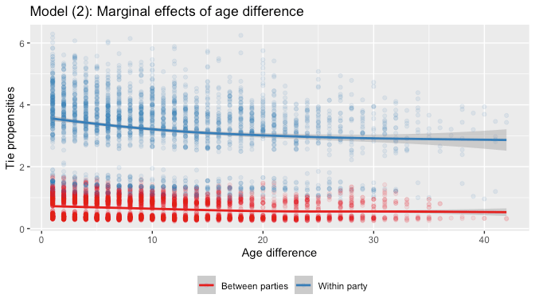

```r
ggplot(nfit2omega, aes(x = age_absdiff, y = omega, color = factor(sameparty)))+
  geom_point(alpha = .1) +
  geom_smooth() + theme(legend.position = 'bottom') +
  scale_color_manual("", values = c('#E41A1C', '#377EB8'), labels = c('Between parties', 'Within party'))+
  xlab("Age difference") + ylab("Tie propensities")+
  ggtitle('Model (2): Marginal effects of age difference')
```

## Network simulations

The `rghype()`-function simulates networks from `nrm`-models. The number of simulations can be specified with the `nsamples` argument.

```r
simnw <- rghype(nsamples = 1, model = nfit2, seed = 1253)
```

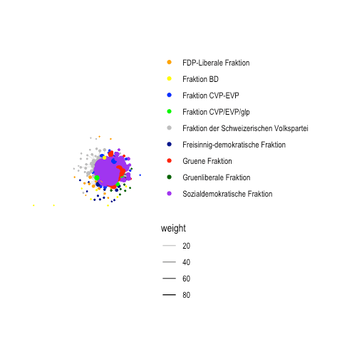

```r
ggraph(graph = simnw, layout = 'stress') +
  geom_edge_link(aes(filter = weight>5, alpha=weight)) +
  geom_node_point(aes(colour = dt$parlGroup), size=10*apply(simnw,1,sum)/max(apply(simnw,1,sum))) +
  scale_colour_manual("", values = c('orange', 'yellow', 'blue', 'green', 'grey',
                                    'darkblue', 'red', 'darkgreen', 'purple')) +
  theme(legend.position = 'bottom') + coord_fixed() + theme_graph()
```